# W3_Exercise_soln

PopBio REU 2018, Reni Kaul; edited by Daniel Suh

6/4/2018; last edited 6/5/2023

# Solving ODEs with lsoda

The function `lsoda()` (Livermore Solver for Ordinary Differential Equations) is part of the `deSolve` package. Let’s start by installing and loading the `deSolve` package

```r
# install package (if not already)
#install.packages("deSolve")
# load library
library(deSolve)
# load some of the other libraries we will need later on
library(tidyverse)
```

Now that the library is loaded, look at the manual page for lsoda. Interpret the first 4 arguments.

- y
- times
- func
- params

*Note: Line within the r chunks starting with* `##` *need to be completed or edited*

## Writing a function for lsoda

Based on the manual page, we know lsoda is expecting a model in the form of `func <- function(t,y,parms)`.

Let’s convert the exponential growth function into this form.

$$\frac{dN}{dt} = rN$$

```r
ExponentialGrowth <- function(t, y, params) {
# Computes the rate of change of the variable y over time
#
# Args:
#   t: vector of time points in the integration
#   y: vector of variables in the differential equation
#   params: vector of parameter values
#
# Returns:
#   The rate of change of the variable y.

  N <- y # create local variable N

  # the argument to "with" lets us use the variable names
  with(as.list(c(params)), {
    dN <- r*N     # Right hand side of the differential equation
    dx <- c(dN) # combine results into a single vector dx
    list(dx) # return list of results
    }
  )
}
```

## Other arguments for lsoda

**Parameters** So now that we have the model written, let’s tackle the other arguments starting with `params`.

What are the parameters in the exponential growth model? What are they called in the `ExponentialGrowth()` function?

*Remember: We can save values to a named object by using redirecting the output using the `<-` syntax*

```r
# the only parameter in the exponential growth model is the grawth rate (r). Let's define r=0.75
parameters <- c(r = 0.75)
```

**Time**

Working backwards the next argument for `lsoda()` is `times`. The solver needs to know when to report the numerical solution for the ODE. Let’s create a vector called `t.vector` starting at 0.1 and increases by 0.1 up to 1.

*Remember: We can save time when making patterned vectors by using* `seq()` *function*

```r
t.vector <- seq(0.1, 1, by = 0.1)
```

**Initial condition of state variable(s)**

The initial condition of the state variable(s) is set by a named vector, just like the parameters values. Let’s create a vector `y0` with an initial state value (N0) of 10.

```r
y0 <- c(N0 = 10)
```

## Run a simulation

We now have a function called `ExponentialGrowth()` that describes the exponential growth model the 3 required arguments for the `lsoda()` function. Let’s simulate the population and save it as an object called `sim1`

```r
sim1 <- lsoda(y = y0, times = t.vector, func = ExponentialGrowth, parms = parameters)
```

What is the population size at the end of the simulation? How would you expect it to change if the growth rate was decreased? Test it out by creating another simulated population named `sim2` with this new growth rate.

```r
parameters2 <- c(r = 0.5) # create a new vector for the params argument
sim2 <- lsoda(y = y0, times = t.vector, func = ExponentialGrowth, parms = parameters2)
```

## Plot the simulation

In some situations, plotting the simulation(s) is more informative than looking at the print out. We can create a scatter plot using `ggplot() + geom_point()` syntax.

Try plotting `sim1` with time on the x-axis.

```r
ggplot(data = sim1, aes(x = time, y = N0)) +
  geom_point()
```

```
## Error in `fortify()`:
## ! `data` must be a <data.frame>, or an object coercible by `fortify()`,
##   not an S3 object with class <deSolve>/<matrix>.
```

You’ll notice that this code returns an error instead of a plot.

Use google, `str()`, `?ggplot()`, and the ggplot cheatsheet to interperet the error. What does the error mean?

```r
str(sim1) # use the `?` to look up the str() function
```

```
##  'deSolve' num [1:10, 1:2] 0.1 0.2 0.3 0.4 0.5 0.6 0.7 0.8 0.9 1 ...
##  - attr(*, "dimnames")=List of 2
##   ..$ : NULL
##   ..$ : chr [1:2] "time" "N0"
##  - attr(*, "istate")= int [1:21] 2 15 31 NA 5 5 0 36 21 NA ...
##  - attr(*, "rstate")= num [1:5] 0.1 0.1 1.04 0 0.1
##  - attr(*, "lengthvar")= int 1
##  - attr(*, "type")= chr "lsoda"
```

```r
#?ggplot()
```

The `ggplot()` function requires data in a data.frame. What is the current object class? Any ideas on how can we convert `sim1` to a data.frame?

*Hint: It is covered in the DataCamp Introduction to R course. If you need a review, check out [DataCarpentry](https://swcarpentry.github.io/r-novice-inflammation/13-supp-data-structures/)*

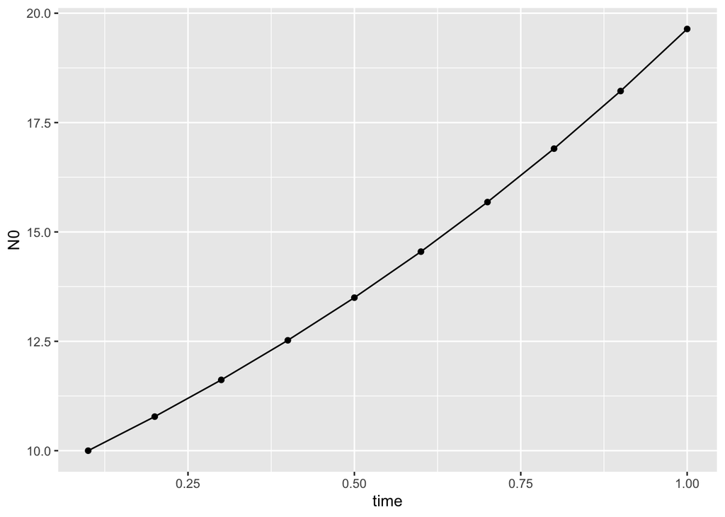

```r
sim1 <- as.data.frame(sim1) # convert sim1 to a data.frame for plotting
sim2 <- as.data.frame(sim2) # convert sim2 to a data.frame as well

# plot sim1 as points
ggplot(data = sim1, aes(x = time, y = N0)) +
  geom_point() +
  geom_line()
```

*Note: The* `sim1 <- as.data.frame(sim1)` *code writes over the old version of sim1.*

### Plotting multiple data objects in a single plot

The `ggplot` syntax has a layered design. You can add layers to the plot by using the `+`. This works for adding different elements for the same dataset like the code chunk above, but also can be used to pull in another dataset.

Let’s use the `geom_point()` and `geom_line()` to add the `sim2` data to the `sim1` plot.

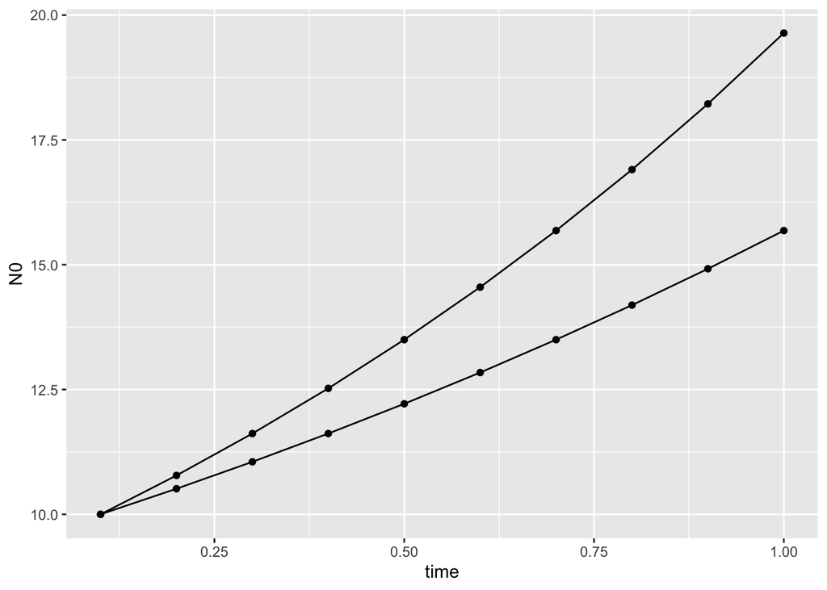

```r
# start with the original sim1 plot
ggplot(data = sim1, aes(x = time, y = N0)) +
  geom_point() +
  geom_line() +
  geom_point(data =sim2, aes(time, N0)) +  # we can add points and lines from sim2 by calling the sim2 data, and defining the aesthetic
  geom_line(data =sim2, aes(time, N0))
```

*Note:*

- The `ggplot()` call can be saved to an object using the `<-`
- layer can be added to the saved object using the same `+` syntax
- The saved `ggplot()` object can be plotted by calling the object

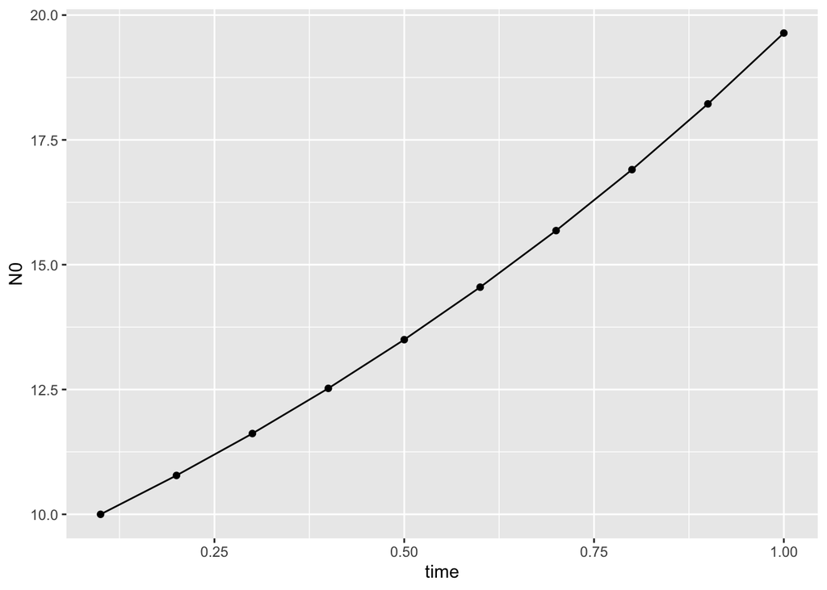

```r
# save the sim1 plot as an object
p <- ggplot(data = sim1, aes(x = time, y = N0)) +
      geom_point() +
      geom_line()

p # call the object p plots the figure
```

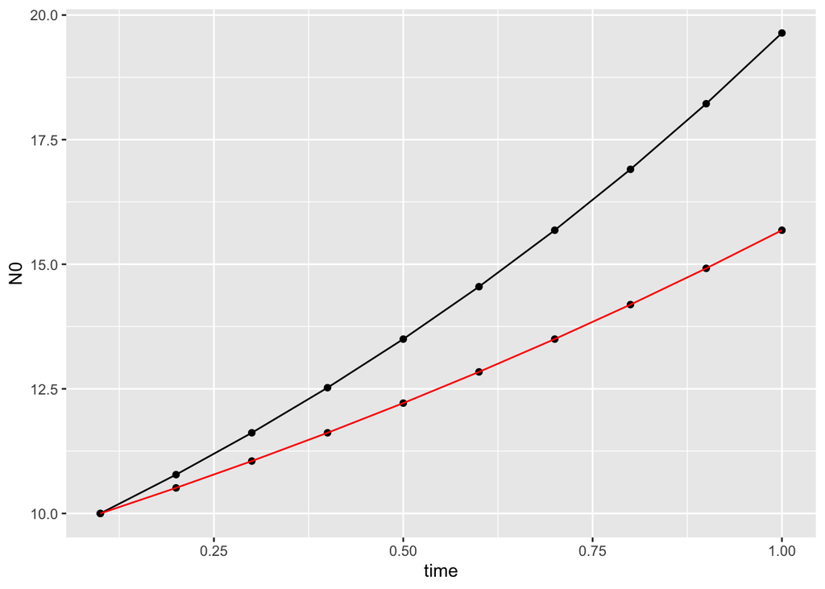

```r
# add sim2 data to the plot `p`
p + geom_point(data = sim2, aes(x = time,y = N0)) +
    geom_line(data = sim2, aes(x = time,y = N0), color = 'red')
```

**Recap:**

- You’ve written a function based on an ODE model
- You’ve simulated data based on an ODE model
- You’ve plotted multiple simulations on the same plot

**Up Next:**

- Break!
- We will simulate a susceptible-infected-recovered (SIR) model

# Simulating an outbreak with an SIR model

You will build on the exponential growth model to make an SIR model and simulate an outbreak. Work in groups of 2-3.

Steps:

1. Using ExponentialGrowth as a guide write a `DensityDepSIR()`
2. Run a simulation using the parameter values (beta, gamma) and initial state conditions (S=,I=,R=)
3. Plot the simulation

## 1. Write `DensityDepSIR()`

The SIR model with density dependent transmission takes the following form:

$$\begin{aligned}
\frac{dS}{dt} &= -\beta SI \\
\frac{dI}{dt} &= \beta SI-\gamma I\\
\frac{dR}{dt} &= \gamma I
\end{aligned}$$

```r
DensityDepSIR <- function(t,x,params){
  # Computes the rate of change of the variables S, I and R over time
   #
   # Args:
   # t: vector of time points in the integration
   # x: vector of variables in the differential equation
   # params: vector of parameter values
   #
   # Returns:
   # The rate of change of the variables S, I and R.

   S <- x[1] #create local variable S, the first element of x
   I <- x[2] #create local variable I
   R <- x[3] #create local variable R


   with( #we can simplify code using "with"
   as.list(params), #this argument to "with" lets us use the variable names
   { #the system of rate equations
     dS <- -beta*S*I
     dI <- beta*S*I-gamma*I
     dR <- gamma*I
     dx <- c(dS,dI,dR) #combine results into a single vector dx
     list(dx) #return result as a list,
     #note order must be same as the state variables
     }
     )
}
```

## 2. Simulate an outbreak

```r
# time points for the integration
t.SIR <-seq(0,120,by=5)

# Initial conditions S,I,R
xstart<- c(S=999/1000,I=1/1000,R=0)

# parameter values
SIRparameters <- c(beta=0.3, gamma=1/7)
```

```r
# simulate an outbreak
SIRsim <- as.data.frame(lsoda(y = xstart, times = t.SIR, func = DensityDepSIR, parms = SIRparameters))
```

## 3. Plot the simulation

The `SIRsim` object is already a data.frame and a single class can be easily plotted using `ggplot()`. How do you think the infected class will change over time? Plot the Infected class to check your thinking.

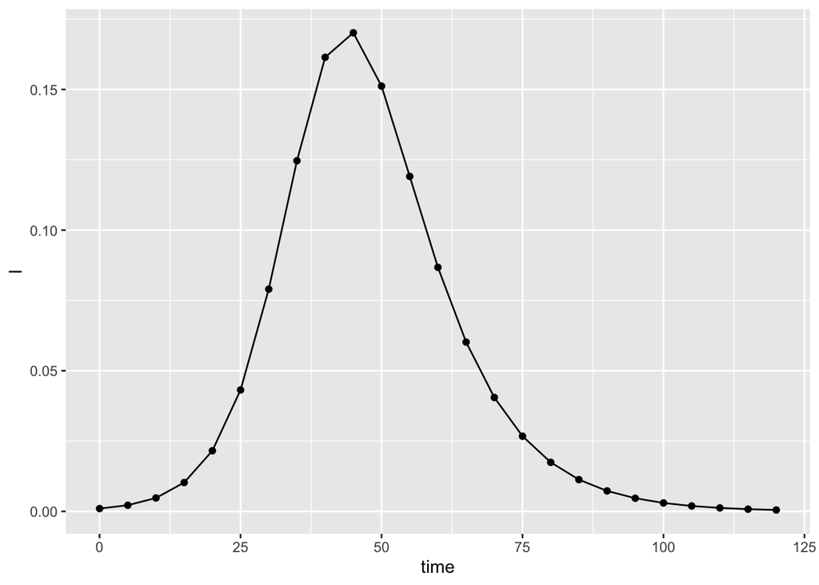

```r
ggplot(data = SIRsim, aes( x = time, y = I)) +
  geom_point() +
  geom_line()
```

The data is currently in wide format (ie. S, I, and R at a given time are all in the same row). We can convert `SIRsim` to long format using the `pivot_longer()` before plotting. The long format data is preferable for data analysis in `R`. If you are already familiar with `R`, then you may have used `gather()` instead of `pivot_longer()`. We recommend switching to `pivot_longer` because it easier to use and more featureful.

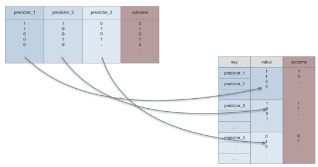

Long format has a single observation per row. See this [blog post](https://sebastiansauerblog.wordpress.com/2016/07/13/long-vs-wide-format-and-gather/) for more details.

Explore the `pivot_longer()` function. Once you have a handle on the `pivot_longer()` function make a new long format `longSIRsim` object and plot.

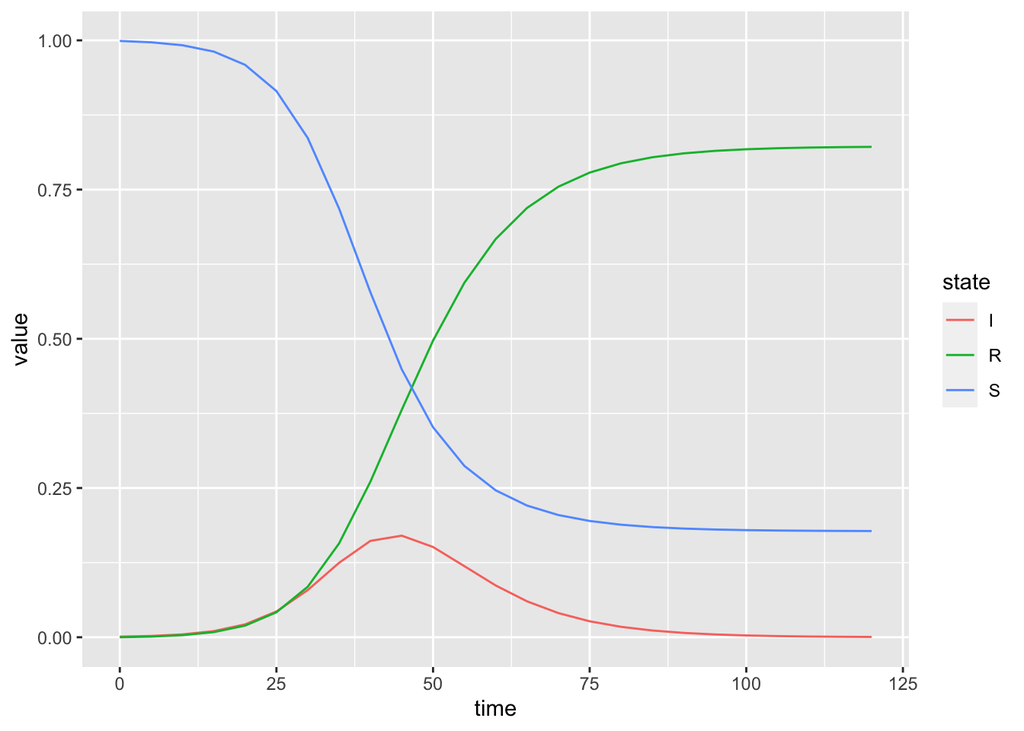

```r
longSIRsim <- SIRsim %>%
              pivot_longer(cols = S:R, names_to = "state", values_to = "value")

ggplot(data = longSIRsim, aes(time, value, color = state)) +
    geom_line()
```

*Note:* Tidyverse pipes can feed directly into ggplot. Here, the `data` argument for `ggplot()` is not needed, the output of the pipe from the line above is automatically used. For consistency, you can use a `.` (period) for the `data` argument but it isn’t required.

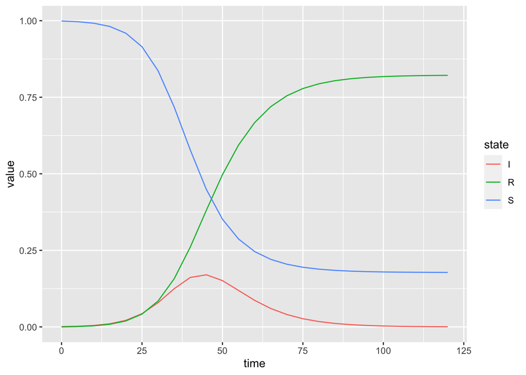

```r
SIRsim %>%
  pivot_longer(cols = S:R, names_to = "state", values_to = "value") %>%  # the gathered data is fed directly into ggplot without creating a secondary object.
  ggplot(data = ., aes(time, value, color = state)) +
    geom_line()
```

**Recap:**

- You’ve simulated and plotted data for an exponential growth model
- You’ve simulated and plotted data for an SIR model

**Up Next:**

- Explore the impact of parameter values on the SIR model

## Challenge: Parameter values of an SIR

Explore the impact of the $\beta$ and $\gamma$ values on the size and duration of the outbreak.

- What happens when $\gamma$ is increased?
- What happens when $\beta$ is increased?
- What happens when the ratio of is held constant but the absolute values change?

Be sure to run your simulations long enough to see the equlibrium values.

*Remember best practices*

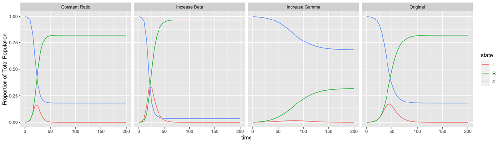

```r
t.SIR <- seq(0,200, 5) # increase simulation length so the all the lines have flattened out

# Increase gamma
betaSIRsim <- as.data.frame(lsoda(y = xstart, times = t.SIR, func = DensityDepSIR, parms = c(beta = 0.5, gamma = 1/7))) %>% mutate(sim = "Increase Beta")

# Increase beta
gammaSIRsim <- as.data.frame(lsoda(y = xstart, times = t.SIR, func = DensityDepSIR, parms = c(beta = 0.3, gamma = 1/4)))  %>% mutate(sim = "Increase Gamma")

# Double both but keep ratio the same
ratioSIRsim <- as.data.frame(lsoda(y = xstart, times = t.SIR, func = DensityDepSIR, parms = c(beta = 0.6, gamma = 2/7)))  %>% mutate(sim = "Constant Ratio")

# Run original parameters but for longer so the same length as the others
SIRsim <- as.data.frame(lsoda(y = xstart, times = t.SIR, func = DensityDepSIR, parms = SIRparameters)) %>% mutate(sim = "Original")

# Plot the 4 different simulations. I added an additional col ("sim") that can be used to make a facet or multi-panel plot quickly

SIRsim %>%
  bind_rows(betaSIRsim, gammaSIRsim, ratioSIRsim) %>%
  pivot_longer(cols = S:R, names_to = "state", values_to = "value") %>%
  ggplot( aes(time, value, color = state)) +
  geom_line() +
  facet_grid(. ~ sim) +
  ylab("Proportion of Total Population")
```

**Recap:**

- You’ve simulated and plotted data for an exponential growth model
- You’ve simulated and plotted data for an SIR model
- Explore the impact of parameter values on the SIR model

**Up Next:**

- Iterating in `R`

# Iteration using exponential growth as an example

The Euler method and the `lsoda()` algorithm are an examples of iteration or repeating a process over and over. Iteration can be a common part of data analysis and is implimented in `R` using loops. Loops come in 3 flavors:

- For loop: repeated a set number of times
- while loop: repeated until a condition is met (could be zero times)
- repeat loop: repeated until a condition is met (completed at least 1 time)

Let’s explore the For loops with the exponential growth model.

**What is population size at next time step?**

We can calculate the $N_{t+1}$ given a population size of 10 and a 2% growth rate ($N_t = 10$ and $r=0.02$).

```r
Nt <- 10 # starting population
r <- 0.02 # population increases 2% each time
Nt1 <- Nt + r*Nt
```

**What is population size at 100th time step?**

We could repeat the previous code chunk 100 times, or use a For loop.

The basic syntax of a `for` loop is:

```r
for(i in 1:10){
  print(i)
}
```

```
## [1] 1
## [1] 2
## [1] 3
## [1] 4
## [1] 5
## [1] 6
## [1] 7
## [1] 8
## [1] 9
## [1] 10
```

What is the output of this loop?

Let’s use the For loop syntax to calculate the population size at t+100

```r
N.seq <- c(rep(0,100)) # make a vector where the calculations will be stored.
N.seq[1] <- 10 # set the current population size to 10

for(i in 1:100){
    N.seq[i+1] <- N.seq[i] + (r*N.seq[i])
}

N.seq
```

```
##   [1] 10.00000 10.20000 10.40400 10.61208 10.82432 11.04081 11.26162 11.48686
##   [9] 11.71659 11.95093 12.18994 12.43374 12.68242 12.93607 13.19479 13.45868
##  [17] 13.72786 14.00241 14.28246 14.56811 14.85947 15.15666 15.45980 15.76899
##  [25] 16.08437 16.40606 16.73418 17.06886 17.41024 17.75845 18.11362 18.47589
##  [33] 18.84541 19.22231 19.60676 19.99890 20.39887 20.80685 21.22299 21.64745
##  [41] 22.08040 22.52200 22.97244 23.43189 23.90053 24.37854 24.86611 25.36344
##  [49] 25.87070 26.38812 26.91588 27.45420 28.00328 28.56335 29.13461 29.71731
##  [57] 30.31165 30.91789 31.53624 32.16697 32.81031 33.46651 34.13584 34.81856
##  [65] 35.51493 36.22523 36.94974 37.68873 38.44251 39.21136 39.99558 40.79549
##  [73] 41.61140 42.44363 43.29250 44.15835 45.04152 45.94235 46.86120 47.79842
##  [81] 48.75439 49.72948 50.72407 51.73855 52.77332 53.82879 54.90536 56.00347
##  [89] 57.12354 58.26601 59.43133 60.61996 61.83236 63.06900 64.33038 65.61699
##  [97] 66.92933 68.26792 69.63328 71.02594 72.44646
```

**Concept check:** What would the N.seq vector look like if the for command was changed to:

- `for(i in 1:50)`?
- `for(i in 50:100)`?

Re-run the loop with the new commands to check your answers.

**Note:**

- For loops are *slow* but easy
- If you need to iterate over more than a few thousand look into using `apply()` functions

DataCamp has a more extensive [tutorial of loops](https://www.datacamp.com/community/tutorials/tutorial-on-loops-in-r)